# covarianceTesting

Recently I've been stumbling on a number of different ways to estimate covariance and how to best optimize one's portfolio for volatility, so I decided to go ahead and test some of them out. I test the effectiveness of different covariance estimators for portfolio optimization using a system similar to that put forth by Pfeiffer and Wendelberger [1] Namely we try to solve:

$$\min(\omega \cdot \Sigma \cdot \omega^{'})$$$$\text{s.t.} \sum^n_{i=1} \omega_i = 1,$$$$\omega^{min} \leq \omega_i \leq \omega^{max},\quad i=1,\ldots,n$$

Where $\omega$ represents a vector of weights representing how much of our portfolio we allocate to a single asset. $\Sigma$ is the covariance matrix

We set $\omega^{min} = 0$ and $\omega^{max} = \frac{1}{10}$.

As a benchmark let us assess the performance of this portfolio using just the sample covariance.

We use 20 years of daily price data from a selection of 135 U.S. midcap equities starting in 2002. All data is retrieved using my very-much-work-in-progress [TD Ameritrade API SDK](https://github.com/quantitatetrading/tda). We perform the backtest using a backtester I purpose built for portfolio optimization problems which can be found [here](https://github.com/BrandtWP/backtester) We set the backtester to rebalance every 20 days.

[1] Pfeiffer, Timo, and Daniel Wendelberger. “Minimum Downside Volatilities.” Solactive, Solactive AG, July 2017, https://www.solactive.com/wp-content/uploads/2018/04/Solactive_Minimum-Downside-Volatility-Indices.pdf.

```python
import psycopg2
import pandas as pd
import pandas_market_calendars as mcal
import numpy as np
import backtester
import tda
import datetime
from os import environ
import saspy
import re
import matplotlib
import json
from scipy.stats import skew, skewtest
matplotlib.rcParams['figure.figsize'] = [16, 9]
```

```python
prices = pd.read_csv('midcapPrices.csv').set_index('Day')
prices.index = pd.to_datetime(prices.index, format=None)

sp500 = pd.read_csv('benchmark.csv').set_index('datetime')['close']
sp500.index = pd.to_datetime(sp500.index).date #Change index from datetime to date in order to agree with the index of our price data
```

```python
def objective(model):
    return sum(model.shares[i] * model.shares[j] * model.covariances[i,j] for i in model.assets for j in model.assets)

def sampleCovariance(logReturns, rebalancePeriod):
    return logReturns.cov() * np.sqrt(rebalancePeriod)

midcapTester = backtester.backtester(prices, debug=False)
```

```
Portfolio value: $368   Progress: [----------------------------------------------------------------------------------------------------] 100% 2022-02-04 00:00:00

Total Return
	 From your porfolio:  259.04%
	 From the benchmark:  212.19%


Average Annualized Return
	 From your porfolio:  13.65%
	 From the benchmark:  12.07%


Maximum Drawdown
	 From your porfolio:  -27.37%
	 From the benchmark:  -34.10%


Information Ratio:  0.22
Sortino Ratio:  0.23
```

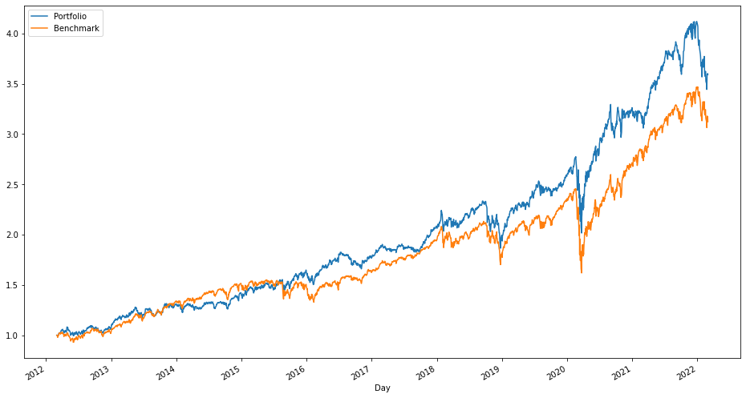

```python
midcapTester.backtest(objective,
                          cash=100,
                          optimizer='cplex',
                          minimumSingleAllocation = 0,
                          maximumSingleAllocation = 1/10,
                          maxLeverage=1,
                          startDate='2012-03-01',
                          rebalancePeriod=20,
                          benchmark=sp500,
                          generateCovariances = sampleCovariance,
                          log=False)
```

While this portfolio performs admirably, Ledoit and Wolf [2] propose a different estimator for the covariance matrix which is verifiably more accurate and well-conditioned (meaning the estimated covariance does not change dramatically given small changes in inputs). They do so not by estimating the covariance matrix $\Sigma$ directly. Instead they try to find the matrix $\Sigma^*$ which has the minimum possible loss ($E[||\Sigma^* - \Sigma||^2]$) where $\Sigma^*$ is structured as a linear combination of the identity matrix and the sample covariance matrix i.e. $\Sigma^* = \rho_1 I + \rho_2 S$. The optimum values of scalars $\rho_1$ and $\rho_2$ depend on the true covariance matrix $\Sigma$ but Ledoit and Wolf go on to provide consistent estimators of them, as follows:

We define the norm of a $p_n$ dimensional matrix to be $\DeclareMathOperator{\tr}{tr} ||A||_n^2 = \frac{\tr(AA^{'})}{p_n}$

We define the inner product of two matrices to be $\langle A_1,A_2 \rangle = \frac{\tr(A_1A_2^{'})}{p_n}$

Given a matrix of observations $X_n$ with dimensions $(p_n \times n)$ we estimate its sample covariance matrix as $S_n = \frac{X_n X_n^{'}}{n}$

$$m_n = \langle S_n,I_n \rangle$$$$d_n^2 = ||S_n - m_n I_n||^2_n$$

Let $x_k^n$ represent the k-th column of $X_n$

$$\bar{b}_n^2=\frac{1}{n^2}\sum^n_{k=1}{||x^n_k(x^n_k)^{'}-S_n||^2_n}$$$$b_n^2 = \min(\bar{b}^2, d^2)$$$$a_n^2 = d_n^2 - b_n^2$$$$S^*_n = \frac{b_n^2}{d_n^2} m_n I_n + \frac{a_n^2}{d_n^2} S_n$$

$S^*_n$ is a consistent estimator of $\Sigma^*$

[2] Olivier Ledoit, Michael Wolf, A well-conditioned estimator for large-dimensional covariance matrices, Journal of Multivariate Analysis, Volume 88, Issue 2, 2004, Pages 365-411, ISSN 0047-259X, https://doi.org/10.1016/S0047-259X(03)00096-4.

```python
def innerProduct(A1, A2):
    return np.trace(np.matmul(A1, A2.T)) / A1.shape[0]

def structuredCovariance(Xn):

    Sn = np.matmul(Xn, Xn.T) / Xn.shape[1]

    mn = innerProduct(Sn, np.identity(Xn.shape[0]))

    dn2 = innerProduct(Sn - mn * np.identity(Xn.shape[0]), Sn - mn * np.identity(Xn.shape[0]))

    bbarn2 = 0

    for k in range(0, Xn.shape[1]):
        columnValue = np.outer(Xn[:, k], Xn[:, k].T) - Sn
        bbarn2 += innerProduct(columnValue, columnValue)

    bbarn2 = 1 / Xn.shape[1]**2 * bbarn2

    bn2 = min(bbarn2, dn2)

    an2 = dn2 - bn2

    return bn2 / dn2 * mn * np.identity(Xn.shape[0]) + an2 / dn2 * Sn
```

```
Portfolio value: $368   Progress: [----------------------------------------------------------------------------------------------------] 100% 2022-02-04 00:00:00

Total Return
	 From your porfolio:  259.37%
	 From the benchmark:  212.19%


Average Annualized Return
	 From your porfolio:  13.66%
	 From the benchmark:  12.07%


Maximum Drawdown
	 From your porfolio:  -27.41%
	 From the benchmark:  -34.10%


Information Ratio:  0.23
Sortino Ratio:  0.23
```

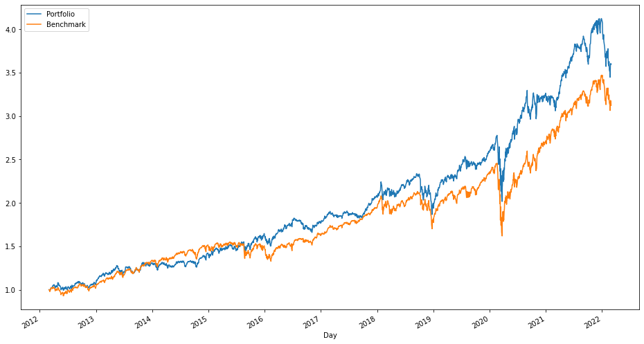

```python
def generateStructuredCovariance(logReturns, rebalancePeriod):
    returns = logReturns.values.T
    return pd.DataFrame(structuredCovariance(returns), columns=prices.columns, index=prices.columns) * np.sqrt(rebalancePeriod)

midcapTester.backtest(objective,
                          cash=100,
                          optimizer='cplex',
                          log=True,
                          minimumSingleAllocation = 0,
                          maximumSingleAllocation = 1/10,
                          startDate='2012-03-01',
                          rebalancePeriod=20,
                          backTestName='structuredCovariance',
                          benchmark=sp500,
                          generateCovariances=generateStructuredCovariance)
```

We observe only marginal differences in portfolio performance between the two estimators. Some expiremtation has satisified me that this result holds accross reasonable variations in the number of observations and number of assets. This corroborates Jagannathan and Ma's [3] result that when imposing a no-short-sales restriction on a portfolio shrinkage estimators do not outperform and can even hurt performance compared to using the sample covariance.

[3] Jagannathan, R., & Tongshu M., (2003). Risk reduction in large portfolios: Why imposing the wrong constraints helps. The Journal of Finance, 58.

The Pfeiffer and Wendelberger go on to suggest using the downside covariance instead of the variance for portfolio optimization. Given a matrix of returns $R$ with $T$ observations and a benchmark return $B$ it calculates the downside covariance $\Sigma^D$ as follows:

$$\Sigma^D_{ijB} = \frac{1}{T} \cdot \sum^T_{t=1}[\min(R_{i,t}-B, 0)\cdot\min(R_{j,t} - B, 0)]$$

Given an $(m \times n)$ matrix $A$ and a scalar $b$ let $$\min(A, b) = \begin{bmatrix} \min(A_{1,1}, b) & \min(A_{1,2},b) & \cdots & \min(A_{1,n-1}, b) & \min(A_{1,n}, b) \\ \min(A_{2,1}, b) & \min(A_{2,2},b) & \cdots & \min(A_{2,n-1}, b) & \min(A_{2,n}, b) \\ \vdots & \vdots & \ddots & \vdots & \vdots \\ \min(A_{m-1,1}, b) & \min(A_{m-1,2},b) & \cdots & \min(A_{m-1,n-1}, b) & \min(A_{m-1,n}, b) \\ \min(A_{m,1}, b) & \min(A_{m,2},b) & \cdots & \min(A_{m,n-1}, b) & \min(A_{m,n}, b) \\ \end{bmatrix}$$

Let us transform our returns matrix $R$ as $R_D = \min(R - B, 0)$ Then $$\Sigma^D_B = \frac{R_D R^t_D}{T}$$

Which simply equals the sample covariance of $R_D$. We likewise adapt the structured covariance estimator cited previously for downside variance by substituting $R_D$ in favor of $R$.

Following this paper's example we set our benchmark $B$ equal to 0 for calculating the downside variance and test it using the same method as previous.

```
Portfolio value: $360   Progress: [----------------------------------------------------------------------------------------------------] 100% 2022-02-04 00:00:00

Total Return
	 From your porfolio:  251.52%
	 From the benchmark:  212.19%


Average Annualized Return
	 From your porfolio:  13.41%
	 From the benchmark:  12.07%


Maximum Drawdown
	 From your porfolio:  -27.47%
	 From the benchmark:  -34.10%


Information Ratio:  0.19
Sortino Ratio:  0.19
```

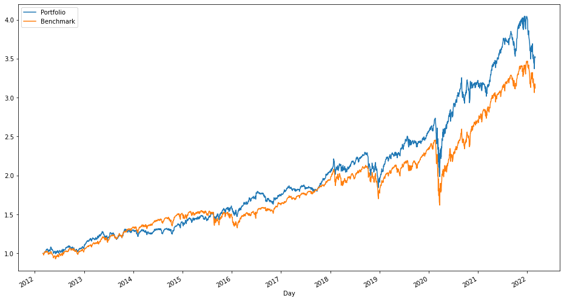

```python
def sampleDownsideCovariance(logReturns, rebalancePeriod):
    returns = np.minimum(logReturns, 0)
    return (returns).cov() * np.sqrt(rebalancePeriod)

midcapTester.backtest(objective,
                          cash=100,
                          optimizer='cplex',
                          minimumSingleAllocation = 0,
                          maximumSingleAllocation = 1/10,
                          maxLeverage=1,
                          startDate='2012-03-01',
                          rebalancePeriod=20,
                          benchmark=sp500,
                          generateCovariances = sampleDownsideCovariance,
                          log=True)
```

```
Portfolio value: $362   Progress: [----------------------------------------------------------------------------------------------------] 100% 2022-02-04 00:00:00

Total Return
	 From your porfolio:  252.69%
	 From the benchmark:  212.19%


Average Annualized Return
	 From your porfolio:  13.45%
	 From the benchmark:  12.07%


Maximum Drawdown
	 From your porfolio:  -28.01%
	 From the benchmark:  -34.10%


Information Ratio:  0.19
Sortino Ratio:  0.20
```

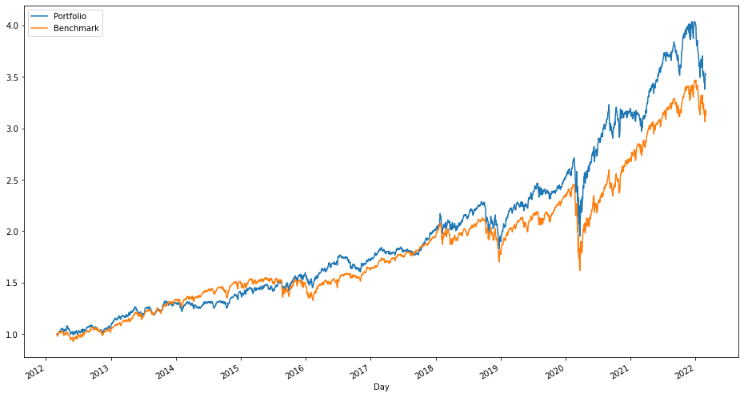

```python
def generateStructuredDownsideCovariance(logReturns, rebalancePeriod):
    returns = np.minimum(logReturns.values.T, 0)
    return pd.DataFrame(structuredCovariance(returns), columns=prices.columns, index=prices.columns) * np.sqrt(rebalancePeriod)

midcapTester.backtest(objective,
                          cash=100,
                          optimizer='cplex',
                          log=True,
                          minimumSingleAllocation = 0,
                          maximumSingleAllocation = 1/10,
                          startDate='2012-03-01',
                          rebalancePeriod=20,
                          backTestName='structuredCovariance',
                          benchmark=sp500,
                          generateCovariances=generateStructuredDownsideCovariance)
```

Once again neither estimator differs much, and in fact the results hardly differ from those with normal covariance matrices. This is odd considering that given the highly statistically significant skewness of the log returns in the data.

```python
skewtest(np.log(sp500 / sp500.shift(1)).dropna())
```

```
SkewtestResult(statistic=-8.568026323365254, pvalue=1.0527373633081004e-17)
```

```python
skewtest(np.log(prices / prices.shift(1)).dropna().mean(1))
```

```
SkewtestResult(statistic=-16.73722924683175, pvalue=7.017970975901556e-63)
```

Evidently, the simple transformation we used fails to meaningfully take this into account.

$\DeclareMathOperator{\GARCH}{GARCH}$ For our next estimator of covariance we model the assets in our data set as a $\GARCH(1,1)$ process.

Let $\epsilon_t$ denote a real-valued discrete-time stochastic process, and $\psi_t$, the information set ($\sigma $-field) of all information through time t. A $\GARCH(p,q)$ process is defined as follows

$$\epsilon_t | \psi_{t-1} \sim N(0,\sigma^2_t)$$$$\sigma^2 = \alpha_0 + \sum^q_{h=1}{\alpha_h \epsilon_{t-h}^2} + \sum^p_{h=1}{\beta_h \sigma^2_{t-h}} $$

To optimize our portfolio we want to generalize this model to a multivariate form that takes into account the covariances of the various time series. We do so by making $\epsilon+t$ a normal vector with covariance matrix $\Sigma_t$

$$\epsilon_t |\psi_{t-1} \sim N(0, \Sigma_t)$$

In accordance with the DCC-GARCH methodology as put forth by Robert Engle [1] We split up the covariance matrix into a diagonal matrix of standard deviations $D_t$ and a matrix of correlations $\Gamma$ thus $\Sigma_t = D_t \Gamma_t D_t$. Assuming GARCH(1,1) we have:

$$\Sigma_t = D_t \Gamma D_t$$$$D_t = \begin{bmatrix} \sigma_{1,t} & 0 & \cdots & 0 & 0 \\ 0 & \sigma_{2,t} & \cdots & 0 & 0 \\ \vdots & \vdots & \ddots & \vdots & \vdots \\ 0 & 0 & \cdots & \sigma_{n-1,t} & 0 \\ 0 & 0 & \cdots & 0 & \sigma_{n,t} \end{bmatrix} $$$$\sigma^2_{i,t} = \omega_{i} + \alpha_{i} \epsilon_{i,t-1}^2 + \beta_{i} \sigma^2_{i, t-1}$$$$\Gamma_t = \begin{bmatrix} 1 & \gamma_{1, 2, t} & \cdots & \gamma_{1, n-1, t} & \gamma_{1,n, t} \\ \gamma_{2, 1, t} & 1 & \cdots & \gamma_{2, n-1, t} & \gamma_{2,n, t} \\ \vdots & \vdots & \ddots & \vdots & \vdots \\ \gamma_{n-1, 1, t} & \gamma_{n-1, 2, t} & \cdots & 1 & \gamma_{n-1,n, t} \\ \gamma_{n, 1, t} & \gamma_{n, 2, t} & \cdots & \gamma_{n, n-1, t} & 1 \end{bmatrix} $$$$\gamma_{ab,t} = \frac{q_{ab,t}}{\sqrt{q_{aa,t} \cdot q_{bb,t}}}$$$$q_{ab,t} = (1 - A - B)\gamma_{ab} + A \frac{\epsilon_{a,t-1}}{\sigma_{aa,t-1}} \frac{\epsilon_{b,t-1}}{\sigma_{bb,t-1}} + B q_{ab,t-1}$$

Note that the $\gamma_ab$ without any associated time $t$ is used to denote a sort-of starting value of $\gamma$ estimated when fitting the model. In fitting our $\text{GARCH}(1,1)$ model we must thus estimate the parameters $(A, B, \omega_1, \ldots, \omega_n, \alpha_1, \ldots, \alpha_n, \beta_1, \ldots, \beta_n, \gamma_{12}, \ldots, \gamma_{n-1, n})$ for a total of $\frac{n(n-1)}{2} + 3n + 2$ parameters.

In general, the log likelihood function for multivariate GARCH models given a set of parameters $\theta$ is $$L(\theta) = -\frac{1}{2}\sum^T_{t=1}{(n\log{2\pi}+\log{|\Sigma_t|} + \epsilon^{'}_t \Sigma_t \epsilon_t)}$$

[1]: Robert Engle (2002) Dynamic Conditional Correlation, Journal of Business & Economic Statistics, 20:3, 339-350, DOI: 10.1198/073500102288618487

```python
sas = saspy.SASsession(cfgfile='sascfg_personal.py')
ets=sas.sasets()
```

```
Using SAS Config named: default
SAS Connection established. Subprocess id is 794709
```

```python
N = 20
modelAssets = np.random.choice(prices.columns, size=N, replace=False)

logReturns = np.log(prices / prices.shift(1)).dropna().reset_index()
sasLogReturns = sas.df2sd(logReturns[modelAssets])

model= ' '.join(modelAssets)
garch = 'p=1 q=1 form=dcc outht=ohdcc'

fittedModel = ets.varmax(data=sasLogReturns, model=model, garch=garch)
```

```python
def varianceTensor(omega, alpha, beta, returns):
    T = len(returns)
    N = returns.shape[1]
    var_t = np.zeros((T, N, N))
    for i in range(T):
        if i==0:
            var_t[i] = np.diag(returns[i]**2)
        else:
            var_t[i] = omega + alpha*(returns[i-1]**2) + beta*var_t[i-1]
    return np.sqrt(var_t)

# def correlationTensor()

def calcQTensor(varianceTensor, startingGamma, A, B, returns):
    T = len(returns)
    N = returns.shape[1]
    Q = np.zeros((T, N, N))

    for i in range(0, T):
        if i == 0:
            Q[i] = (1 - A - B) * startingGamma
        else:
            Q[i] = (1 - A - B) * startingGamma + A * np.outer(returns[i] / np.diagonal(varianceTensor[i]), returns[i] / np.diagonal(varianceTensor[i])) + B*Q[i-1]

    return Q

def correlationTensor(QTensor):
    corrTensor = np.zeros(QTensor.shape)

    for i in range(corrTensor.shape[0]):
        corrTensor[i] = QTensor[i] / np.sqrt(np.outer(np.diag(QTensor[i]), np.diag(QTensor[i])))

    return corrTensor

def covarianceTensor(varTensor, corTensor):
    covTensor = np.zeros(varTensor.shape)
    for i in range(covTensor.shape[0]):
        covTensor[i] = np.matmul(varTensor[i], np.matmul(corTensor[i], varTensor[i]))

    return covTensor
```

```python
def calcDCCGARCH(parameterEstimates, returns):
    N = returns.shape[1]


    parameters = parameterEstimates['Parameter'].apply(lambda x: pd.Series([re.split('\d', x)[0]] + [int(index) -1 for index in re.split('[A-Z](?=\d)|_', x)[1:]]))
    parameters['Estimate'] = parameterEstimates['Estimate']
    parameters.columns = ['Parameter', 'Column_1', 'Column_2', 'Column_3', 'Estimate']
    parameters.loc[~np.isnan(parameters['Column_3']), 'Column_1'] = parameters.loc[~np.isnan(parameters['Column_3']), 'Column_3']
    parameters = parameters.drop('Column_3', axis=1)


    GammaIndices = parameters[['Column_1', 'Column_2']].loc[parameters['Parameter'] == 'DCCS'].values.astype(np.int)

    GammaMatrix = np.zeros((N,N)) + 1
    GammaMatrix[GammaIndices[:, 0], GammaIndices[:, 1]] = parameters.loc[parameters['Parameter'] == 'DCCS', 'Estimate']
    GammaMatrix = GammaMatrix.T
    GammaMatrix[GammaIndices[:, 0], GammaIndices[:, 1]] = parameters.loc[parameters['Parameter'] == 'DCCS', 'Estimate']


    OmegaIndices = parameters[['Column_1', 'Column_2']].loc[parameters['Parameter'] == 'GCHC'].values.astype(np.int)

    OmegaMatrix = np.zeros((N,N))
    OmegaMatrix[OmegaIndices[:, 0], OmegaIndices[:, 1]] = parameters.loc[parameters['Parameter'] == 'GCHC', 'Estimate']


    AlphaIndices = parameters[['Column_1', 'Column_2']].loc[parameters['Parameter'] == 'ACH'].values.astype(np.int)

    AlphaMatrix = np.zeros((N,N))
    AlphaMatrix[AlphaIndices[:, 0], AlphaIndices[:, 1]] = parameters.loc[parameters['Parameter'] == 'ACH', 'Estimate']


    BetaIndices = parameters[['Column_1', 'Column_2']].loc[parameters['Parameter'] == 'GCH'].values.astype(np.int)

    BetaMatrix = np.zeros((N,N))
    BetaMatrix[BetaIndices[:, 0], BetaIndices[:, 1]] = parameters.loc[parameters['Parameter'] == 'GCH', 'Estimate']


    A = parameters.loc[parameters['Parameter'] == 'DCCA', 'Estimate'].values[0]
    B = parameters.loc[parameters['Parameter'] == 'DCCB', 'Estimate'].values[0]

    varTensor = varianceTensor(OmegaMatrix, AlphaMatrix, BetaMatrix, returns)
    QTensor = calcQTensor(varTensor, GammaMatrix, A, B, returns)
    corrTensor = correlationTensor(QTensor)
    covTensor = covarianceTensor(varTensor, corrTensor)

    return {'cov': covTensor, 'corr': corrTensor}
```

In the above code we have taken the parameters fitted in a 20 asset multivariate garch model to compute the assets' covariance and correlation matrices over time. Below we plot the mean correlation of the assets over time. We find spikes during the great recession and during the onset of the covid pandemic. Admittedly, there are some unexplained spikes but the correlation plot largely lines up with one's intuition. Importantly, the graph is a good example of a garch distributed variable and displays how it is able to capture varying variance due to changing market conditions.

```
AxesSubplot(0.125,0.2;0.775x0.68)
```

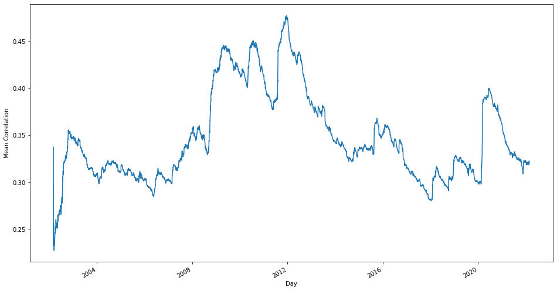

```python
matplotlib.rcParams['figure.figsize'] = [16, 9]

meanCorrelation = []

corrTensor = calcDCCGARCH(fittedModel.GARCHPARAMETERESTIMATES, logReturns[modelAssets].values)['corr']

for i in range(corrTensor.shape[0]):
    meanCorrelation.append(np.mean(corrTensor[i]))

print(pd.Series(meanCorrelation, index=prices.index[1:]).plot(ylabel='Mean Correlation'))
```

Now let's evaluate the DCC-GARCH covariance matrix similarly to as we had done previously but we are restricting the backtester to only 10 randomly sampled assets. We change the upper bound of single-asset-allocation to one third (if it were kept at the one-tenth level there would only be one possible portfolio).

```python
def garchCovariance(logReturns, rebalancePeriod):
    modelAssets = logReturns.columns

    model= ' '.join(modelAssets)
    garch = 'p=1 q=1 form=dcc outht=ohdcc'

    fittedModel = ets.varmax(data=sas.df2sd(logReturns.reset_index()[modelAssets]), model=model, garch=garch)
    return pd.DataFrame(calcDCCGARCH(fittedModel.GARCHPARAMETERESTIMATES, logReturns.values)['cov'][-1] * np.sqrt(rebalancePeriod), index=modelAssets, columns = modelAssets)

N = 10
modelAssets = np.random.choice(prices.columns, size=N, replace=False)

littleTester = backtester.backtester(prices[modelAssets], debug=False)
```

```
Portfolio value: $144   Progress: [----------------------------------------------------------------------------------------------------] 100% 2022-02-04 00:00:00

Total Return
	 From your porfolio:  41.75%
	 From the benchmark:  212.19%


Average Annualized Return
	 From your porfolio:  3.55%
	 From the benchmark:  12.07%


Maximum Drawdown
	 From your porfolio:  -29.62%
	 From the benchmark:  -34.10%


Information Ratio:  -0.69
Sortino Ratio:  -0.68
```

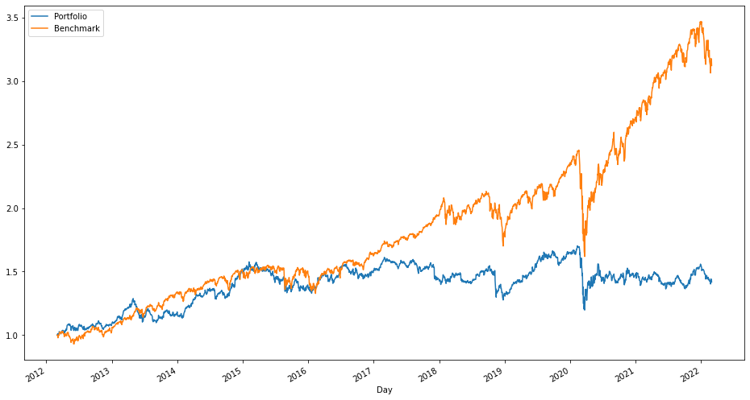

```python
littleTester.backtest(objective,
                          cash=100,
                          optimizer='cplex',
                          minimumSingleAllocation = 0,
                          maximumSingleAllocation = 1/3,
                          maxLeverage=1,
                          startDate='2012-03-01',
                          rebalancePeriod=20,
                          benchmark=sp500,
                          generateCovariances = garchCovariance,
                          log=True,
                          backTestName='garchTest')
```

```
Portfolio value: $164   Progress: [----------------------------------------------------------------------------------------------------] 100% 2022-02-04 00:00:00

Total Return
	 From your porfolio:  59.40%
	 From the benchmark:  212.19%


Average Annualized Return
	 From your porfolio:  4.78%
	 From the benchmark:  12.07%


Maximum Drawdown
	 From your porfolio:  -28.31%
	 From the benchmark:  -34.10%


Information Ratio:  -0.59
Sortino Ratio:  -0.59
```

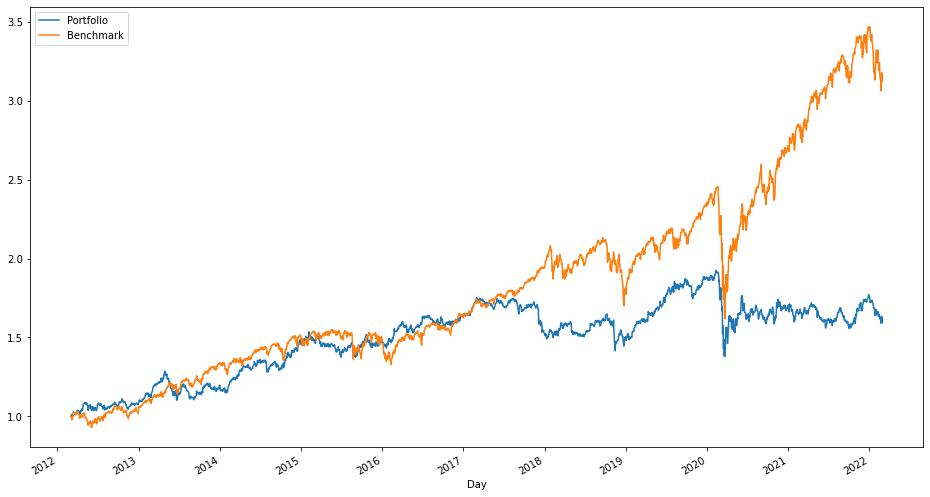

```python
littleTester.backtest(objective,
                          cash=100,
                          optimizer='cplex',
                          minimumSingleAllocation = 0,
                          maximumSingleAllocation = 1/3,
                          maxLeverage=1,
                          startDate='2012-03-01',
                          rebalancePeriod=20,
                          benchmark=sp500,
                          generateCovariances = sampleCovariance,
                          log=True,
                          backTestName='samplecovTest'
                     )
```

Wow! Expectation defying-ly terrible returns! But at least the information and sortino ratios are reasonably different. We even find that

```python
garchPositions = pd.read_csv('logs/garchTest.log', parse_dates=['date']).set_index('date')
garchWeightMatrix = (prices[garchPositions.columns[:-1]] * garchPositions[garchPositions.columns[:-1]]).dropna().divide(garchPositions['cash'].values, axis=0)

samplePositions = pd.read_csv('logs/samplecovTest.log', parse_dates=['date']).set_index('date')
sampleWeightMatrix = (prices[samplePositions.columns[:-1]] * samplePositions[samplePositions.columns[:-1]]).dropna().divide(samplePositions['cash'].values, axis=0)

sp500Vol = np.var(np.log(sp500 / sp500.shift(1)))
garchVol = np.var(np.log(garchPositions['cash'] / garchPositions['cash'].shift(1)))
sampleVol = np.var(np.log(samplePositions['cash'] / samplePositions['cash'].shift(1)))

print("the garch covariance based optimizer has a {:.2f}% higher variance than the sample covariance based optimizer.".format(garchVol / sampleVol * 100 - 100))
```

```
the garch covariance based optimizer has a 12.47% higher variance than the sample covariance based optimizer.
```

The rather disappointing moral of the story for now is then that for basic equities portfolio optimization it's hard to beat the simple sample covariance estimator. But this is most likely a consequence of the simplistic testing environment. I hope to return soon and lift the restriction on short selling in my backtester, expand our data to include commodities -- an asset often used to hedge equities (it was concerning to see that the correlations of returns uin our dataset were almost universally positive ) -- use a TGARCH model which will permit for the modelling of asymmetries in asset returns, and most importantly I want to combine the portfolio optimizer with an alpha signal. What I have in mind is a momentum signal that uses the correlation terms as computed by the DCC-GARCH model to weight the impact of different length trends. Hopefully I'll then be able to post some more interesting results soon.